# Practical Machine Learning Course Project

Mercia Silva

21 April 2016

### Introduction to the Project

This project uses data from http://groupware.les.inf.puc-rio.br/har has data collected from fitness devices located on the belt, forearm, arm, and dumbell of 6 participants who were asked to perform barbell lifts correctly and incorrectly in 5 different ways. The goal is to predict the manner in which they did the exercise. This is the “classe” variable in the training set. Any of the other variables can be used in the prediction.

```r
library(caret)
library(randomForest)
library(rpart)
library(rattle)
```

### The Data

```r
#download.file("http://d396qusza40orc.cloudfront.net/predmachlearn/pml-training.csv", destfile = "pml-training.csv")
#download.file("http://d396qusza40orc.cloudfront.net/predmachlearn/pml-testing.csv", destfile = "pml-testing.csv")
train_data <- read.csv("pml-training.csv", sep = ",", na.strings = c("", "NA"))
result_data <- read.csv("pml-testing.csv", sep = ",", na.strings = c("", "NA"))
```

Having a look at the data with `head(train_data,3)` the data needs to be cleaned removing all NAs

```r
features <- names(result_data[,colSums(is.na(result_data)) == 0])[8:59] #problem_id not on train_data AND remove factors

# Only use features used in submit cases.
train_data <- train_data[,c(features,"classe")] # include classe
result_data <- result_data[,c(features,"problem_id")] # include problem_id
```

The result data is put aside and let’s work only with the train data and dividing the train data into train (75%) and test (25%).

```r
# bootstrap
set.seed(5)
inTrain = createDataPartition(train_data$classe, p = 0.75, list = F)
training = train_data[inTrain,]
testing = train_data[-inTrain,]
```

Using correlation to find the best features to use in the model

```r
# feature selection
outcome = which(names(training) == "classe")
highCorrCols = findCorrelation(abs(cor(training[,-outcome])),0.90)
highCorrFeatures = names(training)[highCorrCols]
highCorrFeatures
```

```
## [1] "accel_belt_z"     "roll_belt"        "accel_belt_y"
## [4] "accel_belt_x"     "gyros_dumbbell_x" "gyros_dumbbell_z"
## [7] "gyros_arm_x"
```

```r
training = training[,-highCorrCols]
outcome = which(names(training) == "classe")
```

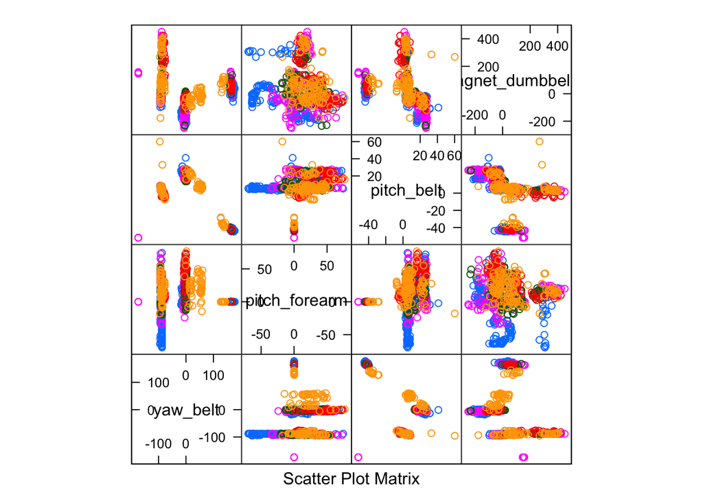

```r
#feature importance
fsRF = randomForest(training[,-outcome], training[,outcome], importance = T)
rfImp = data.frame(fsRF$importance)
impFeatures = order(-rfImp$MeanDecreaseGini)
inImp = createDataPartition(train_data$classe, p = 0.05, list = F)
featurePlot(training[inImp,impFeatures[1:4]],training$classe[inImp], plot = "pairs")
```

Generating/training 3 models to compare: Decision Tree Model, K-Nearest Neighbors Model and Random Forest

```r
modelKNN = train(classe ~ ., training, method = "knn", trControl = trainControl(method = "adaptive_cv"))
modelRF = train(classe ~ ., training, method = "rf", ntree = 200, trControl = trainControl(method = "oob"))
modelDT= train(classe ~ ., training, method="rpart")
resultsKNN = data.frame(modelKNN$results)
resultsRF = data.frame(modelRF$results)
resultsDT = data.frame(modelDT$results)
fitKNN = predict(modelKNN, testing)
fitRF = predict(modelRF, testing)
fitDT = predict(modelDT, testing)
```

Results for the Decision Tree Model:

```r
confusionMatrix(fitDT, testing$classe)$overall
```

```
##       Accuracy          Kappa  AccuracyLower  AccuracyUpper   AccuracyNull
##   4.951060e-01   3.398881e-01   4.810171e-01   5.092008e-01   2.844617e-01
## AccuracyPValue  McnemarPValue
##  7.446777e-212  9.980126e-322
```

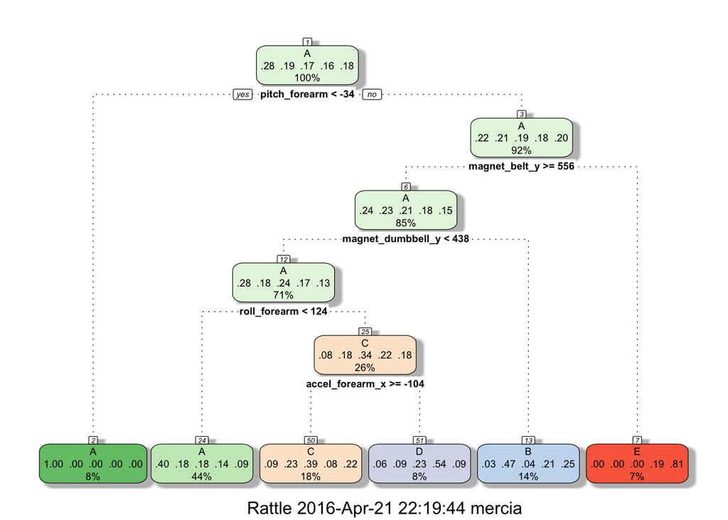

```r
fancyRpartPlot(modelDT$finalModel)
```

Results for the K-Nearest Neighbors Model:

```r
confusionMatrix(fitKNN, testing$classe)$overall
```

```
##       Accuracy          Kappa  AccuracyLower  AccuracyUpper   AccuracyNull
##   9.139478e-01   8.910976e-01   9.057482e-01   9.216506e-01   2.844617e-01
## AccuracyPValue  McnemarPValue
##   0.000000e+00   9.629415e-16
```

Results for the Random Forest Model:

```r
confusionMatrix(fitRF, testing$classe)$overall
```

```
##       Accuracy          Kappa  AccuracyLower  AccuracyUpper   AccuracyNull
##      0.9963295      0.9953570      0.9942053      0.9978232      0.2844617
## AccuracyPValue  McnemarPValue
##      0.0000000            NaN
```

## Conclusion

Thee Random Forest model with Accuracy 0.9963295 is the best performing model.

## Extra

Creating the data to submit to the project quiz:

```r
submit = predict(modelRF, result_data)
answer = data.frame(submit)
answer
```

```
##    submit
## 1       B
## 2       A
## 3       B
## 4       A
## 5       A
## 6       E
## 7       D
## 8       B
## 9       A
## 10      A
## 11      B
## 12      C
## 13      B
## 14      A
## 15      E
## 16      E
## 17      A
## 18      B
## 19      B
## 20      B
```